# Base Plotting System(Swirl)

Mr. Sachin B.

### 1. Base Plotting System

The core plotting and graphics engine in R is encapsulated in two packages.

1. The first is the `graphics` package
   - which contains plotting functions for the “base” system.
   - The functions in this package include `plot`, `hist`, `boxplot`, `barplot`, etc.
2. The second package is `grDevices`
   - which contains all the code implementing the various graphics devices, including X11, PDF, PostScript, PNG, etc.

### 2. Base ‘graphics’ package

- Base graphics are often constructed piecemeal, with each aspect of the plot handled separately through a particular function call.
  - Usually you start with a plot function (such as `plot`, `hist`, or `boxplot`),
  - then you use annotation functions (`text`, `abline`, `points`) to add to or modify your plot.
- Calling a basic routine such as `plot(x, y)` or `hist(x)` launches a `graphics device` (if one is not already open) and draws a new plot on the device.
  - If the arguments to `plot` or `hist` are not of some special class, then the default method is called.
- Most of the base plotting functions have many arguments,
  - for example, setting the title, labels of axes, plot character, etc.
  - Some of the parameters can be set when you call the function or they can be added later in a separate function call.

### 3. Histogram

We’ll use the dataset airquality (part of the library datasets) which we’ve loaded for you. This shows ozone and other air measurements for New York City for 5 months in 1973.

```r
# to see what the data looks like.
head(airquality)
```

```
##   Ozone Solar.R Wind Temp Month Day
## 1    41     190  7.4   67     5   1
## 2    36     118  8.0   72     5   2
## 3    12     149 12.6   74     5   3
## 4    18     313 11.5   62     5   4
## 5    NA      NA 14.3   56     5   5
## 6    28      NA 14.9   66     5   6
```

```r
# Understand range of values in Ozone column excluding 'NA'.
range(airquality$Ozone,na.rm = TRUE)
```

```
## [1]   1 168
```

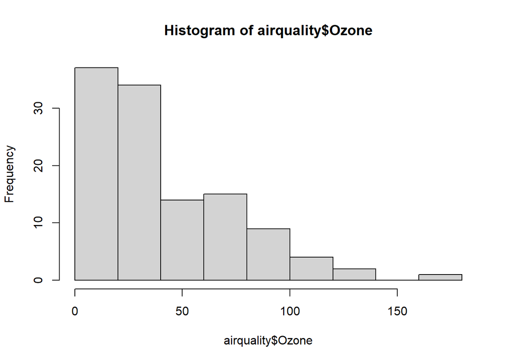

```r
# simple histogram of this ozone column to show the distribution of measurements.
hist(airquality$Ozone)
```

### 4. Boxplot

```r
# Understand no. of values in each Month.
table(airquality$Month)
```

```
##
##  5  6  7  8  9
## 31 30 31 31 30
```

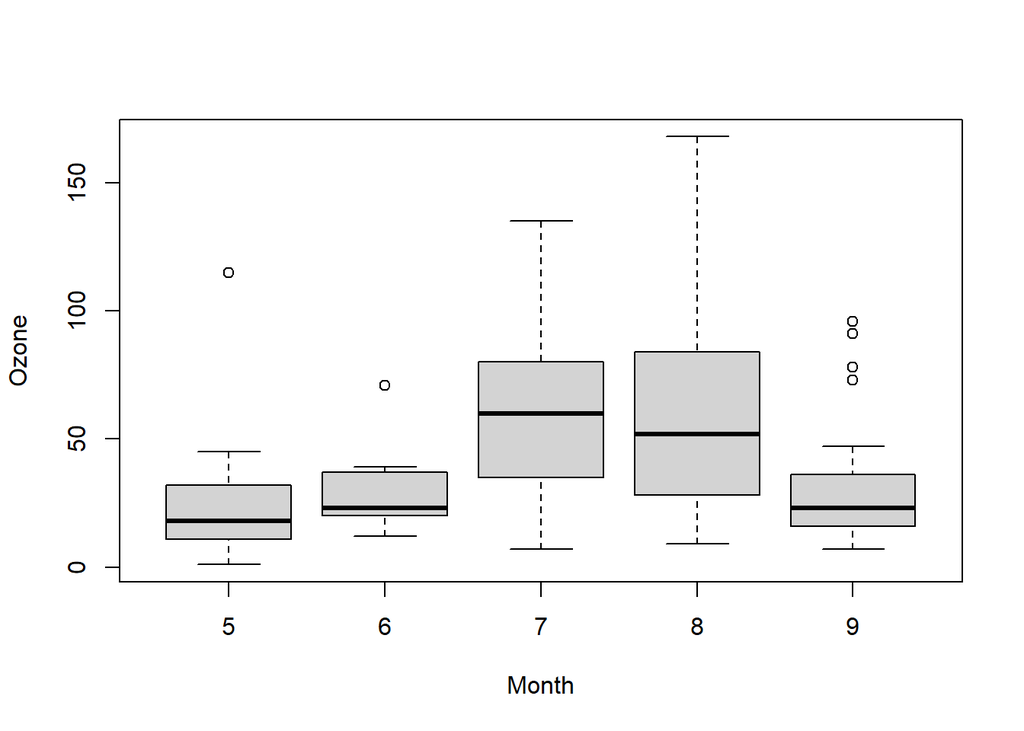

```r
# boxplot of 'ozone' as a function of the 'Month'
boxplot(Ozone~Month,airquality)
```

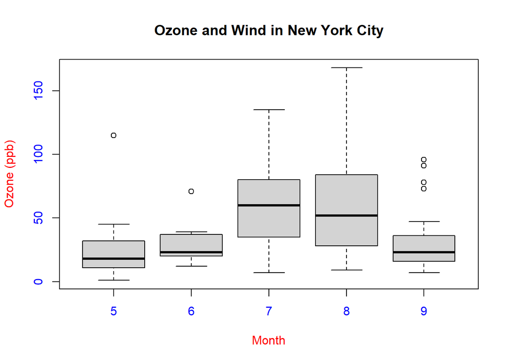

```r
# Let's call boxplot again to specify labels.
# We'll add more arguments to the call to specify labels for the 2 axes. ## Set xlab equal to "Month" and ylab equal to "Ozone (ppb)".
## Specify col.axis equal to "blue" and col.lab equal to "red".

boxplot(Ozone~Month, airquality, xlab = "Month", ylab = "Ozone (ppb)", col.axis = "blue", col.lab = "red")

# Use the argument main set equal to the string "Ozone and Wind in New York City".

title(main = "Ozone and Wind in New York City")
```

### 5. Scatter Plot

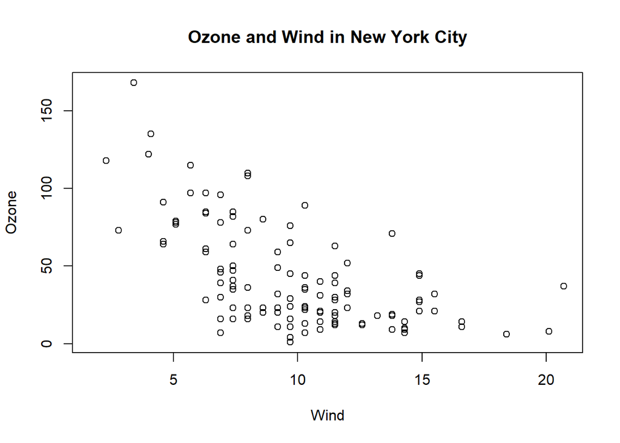

```r
# We'll show the relationship between Wind (x-axis) and Ozone (y-axis). # We'll use the function plot with those two arguments (Wind and Ozone, in that order).

with(airquality,plot(Wind,Ozone))

# Add Title

title(main = "Ozone and Wind in New York City")
```

### 6. par()

- The basic plotting parameters are documented in the R help page for the function `par`.
- You can use `par` to set parameters OR to find out what values are already set.

```r
# To see just how much flexibility we have, we will run the R command `length` with the argument `par()` now.
length(par())
```

```
## [1] 72
```

```r
# R function `names` with `par()` as its argument to see what these parameters are.
names(par())
```

```
##  [1] "xlog"      "ylog"      "adj"       "ann"       "ask"       "bg"
##  [7] "bty"       "cex"       "cex.axis"  "cex.lab"   "cex.main"  "cex.sub"
## [13] "cin"       "col"       "col.axis"  "col.lab"   "col.main"  "col.sub"
## [19] "cra"       "crt"       "csi"       "cxy"       "din"       "err"
## [25] "family"    "fg"        "fig"       "fin"       "font"      "font.axis"
## [31] "font.lab"  "font.main" "font.sub"  "lab"       "las"       "lend"
## [37] "lheight"   "ljoin"     "lmitre"    "lty"       "lwd"       "mai"
## [43] "mar"       "mex"       "mfcol"     "mfg"       "mfrow"     "mgp"
## [49] "mkh"       "new"       "oma"       "omd"       "omi"       "page"
## [55] "pch"       "pin"       "plt"       "ps"        "pty"       "smo"
## [61] "srt"       "tck"       "tcl"       "usr"       "xaxp"      "xaxs"
## [67] "xaxt"      "xpd"       "yaxp"      "yaxs"      "yaxt"      "ylbias"
```

```r
# Default Value for Plot dimensions in inches
par()$pin
```

```
## [1] 5.759999 3.159999
```

```r
#OR
par("pin")
```

```
## [1] 5.759999 3.159999
```

```r
# Default Color for Foreground
par("fg")
```

```
## [1] "black"
```

```r
# The plot character default is the open circle, but it "can either be a single character or an integer code for one of a set of graphics symbols."
par("pch")
```

```
## [1] 1
```

```r
# par("lty") to see the default line type
par("lty")
```

```
## [1] "solid"
```

#### 6.1 Color

- The plotting color, specified as a number, string, or hex code;
- the `colors()` function gives you a vector of colors by name.

```r
colors()
```

#### 6.2 How to reset ‘par’ values to default

- The par() function is used to specify global graphics parameters that affect all plots in an R session.
- These parameters can be overridden when specified as arguments to specific plotting functions.
  - These include las (the orientation of the axis labels on the plot),
  - bg (background color),
  - mar (margin size),
  - oma (outer margin size),
  - mfrow and mfcol (number of plots per row, column).
- **Use `dev.off` or `plot.new` to reset to the defaults**.

### 7. type = “n”

This tells R to set up the plot but not to put the data in it.

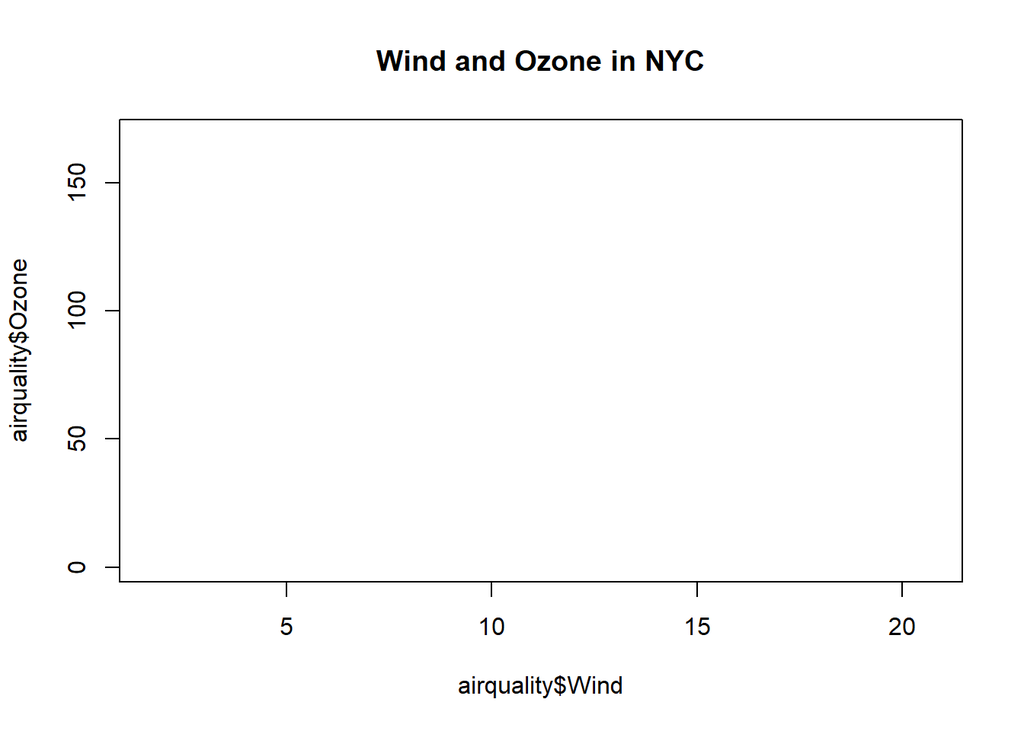

```r
plot(airquality$Wind,airquality$Ozone, type = "n")

# Add a title with the argument main set equal to the string "Wind and Ozone in NYC"

title("Wind and Ozone in NYC")
```

#### 7.1 Adding ‘points’ to blank plot alongwith ‘legend’ & ‘abline’

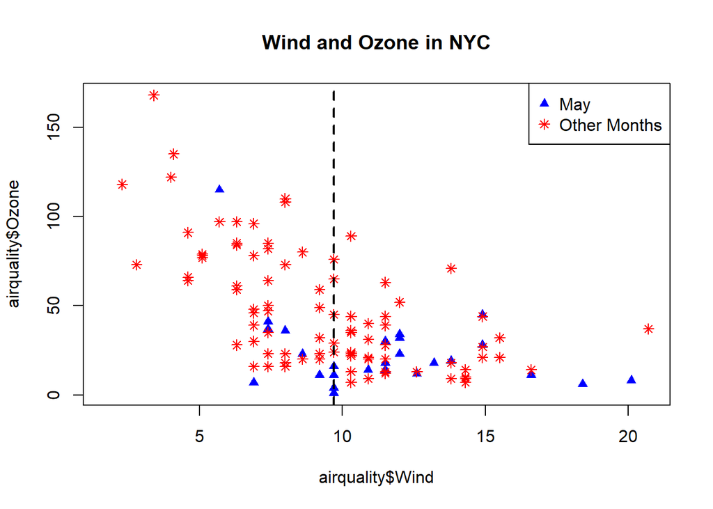

```r
# Repeating from earlier command
plot(airquality$Wind,airquality$Ozone, type = "n")
title("Wind and Ozone in NYC")

# Now create a variable called `may` by subsetting airquality appropriately.

may <- subset(airquality,Month==5)

# R command points to plot May's wind and ozone (in that order) as solid blue triangles.

points(may$Wind,may$Ozone,col="blue",pch=17) # pch=17 for Solid Triangle

# Now create the variable `notmay` by subsetting airquality appropriately.
notmay<- subset(airquality,Month!=5)

# R command points to plot these notmay's wind and ozone (in that order) as red snowflakes.

points(notmay$Wind,notmay$Ozone,col="red",pch=8)  # pch=8 for snowflakes

# R command `legend` to clarify the plot and explain what it means.
  ## The first arg will be the string "topright" to tell R where to put the legend.
  ## The remaining 3 arguments will each be 2-long vectors created by R's concatenate function, e.g., c(). These arguments are pch, col, and legend.

legend("topright",pch = c(17,8),col = c('blue','red'),legend = c("May","Other Months"))

# add a vertical line at the median of airquality$Wind. Make it dashed
abline(v=median(airquality$Wind),lty=2,lwd=2) # lty=2 for dashed line.
```

### 8. Multiple Plots

- The last two, `mfrow` and `mfcol`, both deal with multiple plots in that they specify the number of plots per row and column.
- The difference between them is the order in which they fill the plot matrix.
  - The call `mfrow` will fill the rows first
  - `mfcol` fills the columns first.

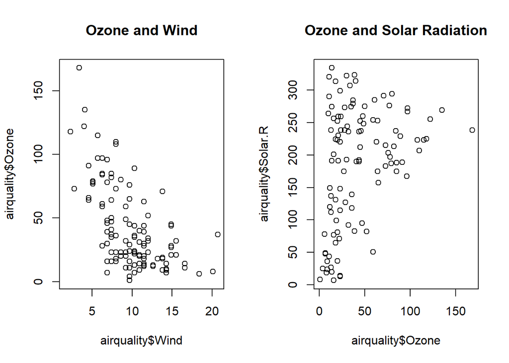

```r
# Use par with the parameter mfrow set equal to the vector (1,2) to set up the plot window for two plots side by side.

par(mfrow=c(1,2))

# First Plot: plot airquality$Wind and airquality$Ozone and use main to specify the title "Ozone and Wind".

plot(airquality$Wind,airquality$Ozone, main = "Ozone and Wind")

# Second Plot: Plot airquality$Ozone and airquality$Solar.R and use main to specify the title "Ozone and Solar Radiation".

plot(airquality$Ozone,airquality$Solar.R, main = "Ozone and Solar Radiation")
```

#### ‘margin’ (‘mar’ & ‘oma’) & ‘mtext’

This one with 3 plots, to illustrate inner and outer margins.

- Margins are specified as 4-long vectors of integers.
  - Each number tells how many lines of text to leave at each side.
  - The numbers are assigned clockwise starting at the bottom.
  - The default for the inner margin is c(5.1, 4.1, 4.1, 2.1) so you can see we reduced each of these so we’ll have room for some outer text.

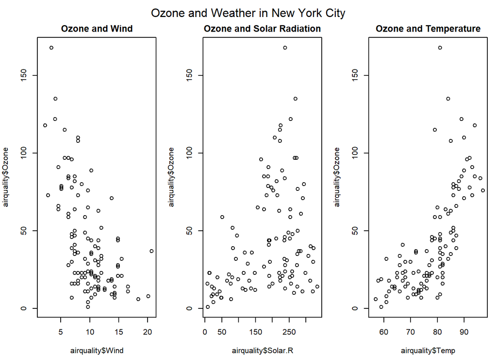

```r
par(mfrow = c(1,3), mar = c(4, 4, 2, 1), oma = c(0, 0, 2, 0))

# Add 3 Plots

## Plot 1
plot(airquality$Wind,airquality$Ozone, main = "Ozone and Wind")

## Plot 2
plot(airquality$Solar.R,airquality$Ozone, main = "Ozone and Solar Radiation")

## Plot 3
plot(airquality$Temp, airquality$Ozone, main = "Ozone and Temperature")


# Since this is the main title, we specify it with the R command mtext.
mtext("Ozone and Weather in New York City",outer = TRUE)
```